# sample

Autogenerated data summary from dataMaid

2020-11-05 19:37:43

# Data report overview

The dataset examined has the following dimensions:

| Feature | Result |
| --- | --- |
| Number of observations | 28534 |
| Number of variables | 3 |

National Longitudinal Survey. Young Women 14-26 years of age in 1968

### Checks performed

The following variable checks were performed, depending on the data type of each variable:

|  | character | factor | labelled | haven labelled | numeric | integer | logical | Date |
| --- | --- | --- | --- | --- | --- | --- | --- | --- |
| Identify miscoded missing values | $\times$ | $\times$ | $\times$ | $\times$ | $\times$ | $\times$ |  | $\times$ |
| Identify prefixed and suffixed whitespace | $\times$ | $\times$ | $\times$ | $\times$ |  |  |  |  |
| Identify levels with < 6 obs. | $\times$ | $\times$ | $\times$ | $\times$ |  |  |  |  |
| Identify case issues | $\times$ | $\times$ | $\times$ | $\times$ |  |  |  |  |
| Identify misclassified numeric or integer variables | $\times$ | $\times$ | $\times$ | $\times$ |  |  |  |  |
| Identify outliers |  |  |  |  | $\times$ | $\times$ |  | $\times$ |

Please note that all numerical values in the following have been rounded to 2 decimals.

# Summary table

|  | Variable class | # unique values | Missing observations | Any problems? |
| --- | --- | --- | --- | --- |
| age | numeric | 34 | 0.08 % |  |
| tenure | numeric | 271 | 1.52 % |  |
| ln_wage | numeric | 8173 | 0.00 % | $\times$ |

# Variable list

## age

*age in current year*

| Feature | Result |
| --- | --- |
| Variable type | numeric |
| Number of missing obs. | 24 (0.08 %) |
| Number of unique values | 33 |
| Median | 28 |
| 1st and 3rd quartiles | 23; 34 |
| Min. and max. | 14; 46 |

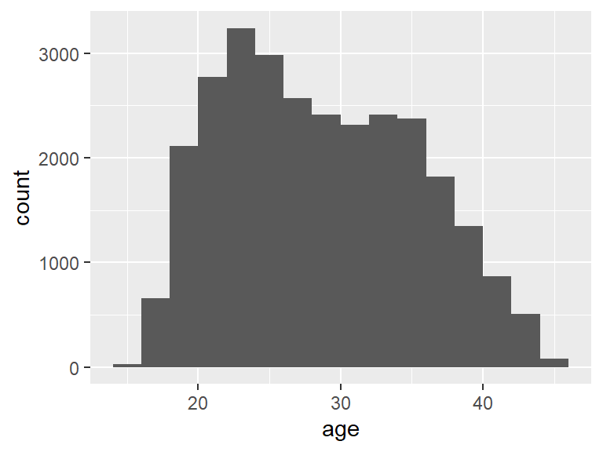

## tenure

*job tenure, in years*

| Feature | Result |
| --- | --- |
| Variable type | numeric |
| Number of missing obs. | 433 (1.52 %) |
| Number of unique values | 270 |
| Median | 1.67 |
| 1st and 3rd quartiles | 0.5; 4.17 |
| Min. and max. | 0; 25.92 |

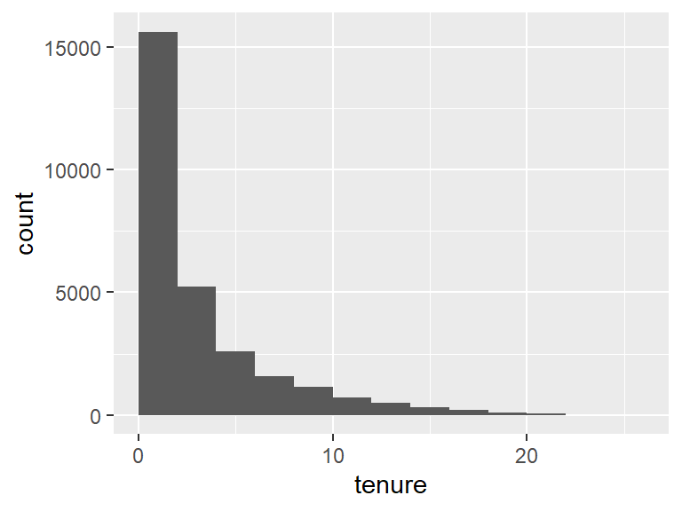

## ln_wage

*ln(wage/GNP deflator)*

| Feature | Result |
| --- | --- |
| Variable type | numeric |
| Number of missing obs. | 0 (0 %) |
| Number of unique values | 8173 |
| Median | 1.64 |
| 1st and 3rd quartiles | 1.36; 1.96 |
| Min. and max. | 0; 5.26 |

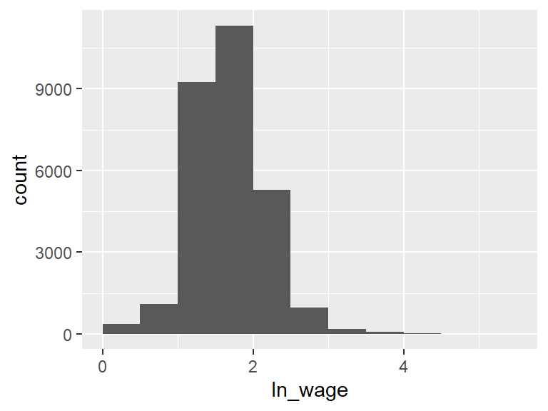

- Note that the following possible outlier values were detected: "0", "0", "0", "0.01", "0.02", "0.02", "0.02", "0.03", "0.03", "0.03" (448 additional values omitted).

Report generation information:

- Created by: Miguel Portela (username: `mangelo`).
- Report creation time: qui nov 05 2020 19:37:44
- Report was run from directory: `C:/Users/mangelo.EEG/Documents/GitHub/R_Training/jupyter`
- dataMaid v1.4.0 [Pkg: 2019-12-10 from CRAN (R 4.0.3)]
- R version 4.0.3 (2020-10-10).
- Platform: x86_64-w64-mingw32/x64 (64-bit)(Windows 10 x64 (build 18362)).
- Function call: `makeDataReport(data = sample, render = FALSE, file = "sample.Rmd", replace = TRUE)`